# Risk Factor Analysis

## Outcome Variable

**Outcome Variable:** wasted

## Predictor Variables

**Intervention Variable:** exclfeed6

**Adjustment Set:**

unadjusted

## Stratifying Variables

The analysis was stratified on these variable(s):

- agecat
- studyid
- country

## Data Summary

| agecat | studyid | country | exclfeed6 | wasted | n_cell | n |
| --- | --- | --- | --- | --- | --- | --- |
| Birth | ki0047075b-MAL-ED | BANGLADESH | 0 | 0 | 136 | 219 |
| Birth | ki0047075b-MAL-ED | BANGLADESH | 0 | 1 | 30 | 219 |
| Birth | ki0047075b-MAL-ED | BANGLADESH | 1 | 0 | 45 | 219 |
| Birth | ki0047075b-MAL-ED | BANGLADESH | 1 | 1 | 8 | 219 |
| Birth | ki0047075b-MAL-ED | BRAZIL | 0 | 0 | 151 | 168 |
| Birth | ki0047075b-MAL-ED | BRAZIL | 0 | 1 | 6 | 168 |
| Birth | ki0047075b-MAL-ED | BRAZIL | 1 | 0 | 11 | 168 |
| Birth | ki0047075b-MAL-ED | BRAZIL | 1 | 1 | 0 | 168 |
| Birth | ki0047075b-MAL-ED | INDIA | 0 | 0 | 152 | 187 |
| Birth | ki0047075b-MAL-ED | INDIA | 0 | 1 | 30 | 187 |
| Birth | ki0047075b-MAL-ED | INDIA | 1 | 0 | 5 | 187 |
| Birth | ki0047075b-MAL-ED | INDIA | 1 | 1 | 0 | 187 |
| Birth | ki0047075b-MAL-ED | NEPAL | 0 | 0 | 134 | 165 |
| Birth | ki0047075b-MAL-ED | NEPAL | 0 | 1 | 20 | 165 |
| Birth | ki0047075b-MAL-ED | NEPAL | 1 | 0 | 11 | 165 |
| Birth | ki0047075b-MAL-ED | NEPAL | 1 | 1 | 0 | 165 |
| Birth | ki0047075b-MAL-ED | PERU | 0 | 0 | 234 | 249 |
| Birth | ki0047075b-MAL-ED | PERU | 0 | 1 | 5 | 249 |
| Birth | ki0047075b-MAL-ED | PERU | 1 | 0 | 10 | 249 |
| Birth | ki0047075b-MAL-ED | PERU | 1 | 1 | 0 | 249 |
| Birth | ki0047075b-MAL-ED | SOUTH AFRICA | 0 | 0 | 195 | 209 |
| Birth | ki0047075b-MAL-ED | SOUTH AFRICA | 0 | 1 | 14 | 209 |
| Birth | ki0047075b-MAL-ED | SOUTH AFRICA | 1 | 0 | 0 | 209 |
| Birth | ki0047075b-MAL-ED | SOUTH AFRICA | 1 | 1 | 0 | 209 |
| Birth | ki0047075b-MAL-ED | TANZANIA, UNITED REPUBLIC OF | 0 | 0 | 112 | 115 |
| Birth | ki0047075b-MAL-ED | TANZANIA, UNITED REPUBLIC OF | 0 | 1 | 2 | 115 |
| Birth | ki0047075b-MAL-ED | TANZANIA, UNITED REPUBLIC OF | 1 | 0 | 1 | 115 |
| Birth | ki0047075b-MAL-ED | TANZANIA, UNITED REPUBLIC OF | 1 | 1 | 0 | 115 |
| Birth | ki1000108-CMC-V-BCS-2002 | INDIA | 0 | 0 | 0 | 7 |
| Birth | ki1000108-CMC-V-BCS-2002 | INDIA | 0 | 1 | 0 | 7 |

[output cut: 158 more lines]

The following strata were considered:

- agecat: 24 months, studyid: ki0047075b-MAL-ED, country: BANGLADESH
- agecat: 24 months, studyid: ki0047075b-MAL-ED, country: BRAZIL
- agecat: 24 months, studyid: ki0047075b-MAL-ED, country: INDIA
- agecat: 24 months, studyid: ki0047075b-MAL-ED, country: NEPAL
- agecat: 24 months, studyid: ki0047075b-MAL-ED, country: PERU
- agecat: 24 months, studyid: ki0047075b-MAL-ED, country: SOUTH AFRICA
- agecat: 24 months, studyid: ki0047075b-MAL-ED, country: TANZANIA, UNITED REPUBLIC OF
- agecat: 24 months, studyid: ki1000108-CMC-V-BCS-2002, country: INDIA
- agecat: 24 months, studyid: ki1000108-IRC, country: INDIA
- agecat: 24 months, studyid: ki1017093b-PROVIDE, country: BANGLADESH
- agecat: 24 months, studyid: ki1101329-Keneba, country: GAMBIA
- agecat: 24 months, studyid: ki1113344-GMS-Nepal, country: NEPAL
- agecat: 24 months, studyid: ki1148112-LCNI-5, country: MALAWI
- agecat: 24 months, studyid: kiGH5241-JiVitA-3, country: BANGLADESH
- agecat: 24 months, studyid: kiGH5241-JiVitA-4, country: BANGLADESH
- agecat: 6 months, studyid: ki0047075b-MAL-ED, country: BANGLADESH
- agecat: 6 months, studyid: ki0047075b-MAL-ED, country: BRAZIL
- agecat: 6 months, studyid: ki0047075b-MAL-ED, country: INDIA
- agecat: 6 months, studyid: ki0047075b-MAL-ED, country: NEPAL
- agecat: 6 months, studyid: ki0047075b-MAL-ED, country: PERU
- agecat: 6 months, studyid: ki0047075b-MAL-ED, country: SOUTH AFRICA
- agecat: 6 months, studyid: ki0047075b-MAL-ED, country: TANZANIA, UNITED REPUBLIC OF
- agecat: 6 months, studyid: ki1000108-CMC-V-BCS-2002, country: INDIA
- agecat: 6 months, studyid: ki1000108-IRC, country: INDIA
- agecat: 6 months, studyid: ki1000109-EE, country: PAKISTAN
- agecat: 6 months, studyid: ki1000304b-SAS-CompFeed, country: INDIA
- agecat: 6 months, studyid: ki1000304b-SAS-FoodSuppl, country: INDIA
- agecat: 6 months, studyid: ki1017093b-PROVIDE, country: BANGLADESH
- agecat: 6 months, studyid: ki1101329-Keneba, country: GAMBIA
- agecat: 6 months, studyid: ki1113344-GMS-Nepal, country: NEPAL
- agecat: 6 months, studyid: ki1148112-LCNI-5, country: MALAWI
- agecat: 6 months, studyid: kiGH5241-JiVitA-3, country: BANGLADESH
- agecat: 6 months, studyid: kiGH5241-JiVitA-4, country: BANGLADESH
- agecat: Birth, studyid: ki0047075b-MAL-ED, country: BANGLADESH
- agecat: Birth, studyid: ki0047075b-MAL-ED, country: BRAZIL
- agecat: Birth, studyid: ki0047075b-MAL-ED, country: INDIA
- agecat: Birth, studyid: ki0047075b-MAL-ED, country: NEPAL
- agecat: Birth, studyid: ki0047075b-MAL-ED, country: PERU
- agecat: Birth, studyid: ki0047075b-MAL-ED, country: SOUTH AFRICA
- agecat: Birth, studyid: ki0047075b-MAL-ED, country: TANZANIA, UNITED REPUBLIC OF
- agecat: Birth, studyid: ki1000108-CMC-V-BCS-2002, country: INDIA
- agecat: Birth, studyid: ki1000108-IRC, country: INDIA
- agecat: Birth, studyid: ki1000109-EE, country: PAKISTAN
- agecat: Birth, studyid: ki1000304b-SAS-CompFeed, country: INDIA
- agecat: Birth, studyid: ki1101329-Keneba, country: GAMBIA
- agecat: Birth, studyid: kiGH5241-JiVitA-3, country: BANGLADESH
- agecat: Birth, studyid: kiGH5241-JiVitA-4, country: BANGLADESH

### Dropped Strata

Some strata were dropped due to rare outcomes:

- agecat: Birth, studyid: ki0047075b-MAL-ED, country: BRAZIL
- agecat: Birth, studyid: ki0047075b-MAL-ED, country: INDIA
- agecat: Birth, studyid: ki0047075b-MAL-ED, country: NEPAL
- agecat: Birth, studyid: ki0047075b-MAL-ED, country: PERU
- agecat: Birth, studyid: ki0047075b-MAL-ED, country: SOUTH AFRICA
- agecat: Birth, studyid: ki0047075b-MAL-ED, country: TANZANIA, UNITED REPUBLIC OF
- agecat: Birth, studyid: ki1000108-CMC-V-BCS-2002, country: INDIA
- agecat: Birth, studyid: ki1000108-IRC, country: INDIA
- agecat: Birth, studyid: ki1000109-EE, country: PAKISTAN
- agecat: Birth, studyid: ki1000304b-SAS-CompFeed, country: INDIA
- agecat: Birth, studyid: kiGH5241-JiVitA-4, country: BANGLADESH
- agecat: 6 months, studyid: ki0047075b-MAL-ED, country: BANGLADESH
- agecat: 6 months, studyid: ki0047075b-MAL-ED, country: BRAZIL
- agecat: 6 months, studyid: ki0047075b-MAL-ED, country: INDIA
- agecat: 6 months, studyid: ki0047075b-MAL-ED, country: NEPAL
- agecat: 6 months, studyid: ki0047075b-MAL-ED, country: PERU
- agecat: 6 months, studyid: ki0047075b-MAL-ED, country: SOUTH AFRICA
- agecat: 6 months, studyid: ki0047075b-MAL-ED, country: TANZANIA, UNITED REPUBLIC OF
- agecat: 6 months, studyid: ki1000108-CMC-V-BCS-2002, country: INDIA
- agecat: 6 months, studyid: ki1000108-IRC, country: INDIA
- agecat: 6 months, studyid: ki1000304b-SAS-CompFeed, country: INDIA
- agecat: 6 months, studyid: ki1000304b-SAS-FoodSuppl, country: INDIA
- agecat: 6 months, studyid: ki1017093b-PROVIDE, country: BANGLADESH
- agecat: 6 months, studyid: ki1148112-LCNI-5, country: MALAWI
- agecat: 24 months, studyid: ki0047075b-MAL-ED, country: BRAZIL
- agecat: 24 months, studyid: ki0047075b-MAL-ED, country: INDIA
- agecat: 24 months, studyid: ki0047075b-MAL-ED, country: NEPAL
- agecat: 24 months, studyid: ki0047075b-MAL-ED, country: PERU
- agecat: 24 months, studyid: ki0047075b-MAL-ED, country: SOUTH AFRICA
- agecat: 24 months, studyid: ki0047075b-MAL-ED, country: TANZANIA, UNITED REPUBLIC OF
- agecat: 24 months, studyid: ki1000108-CMC-V-BCS-2002, country: INDIA
- agecat: 24 months, studyid: ki1000108-IRC, country: INDIA
- agecat: 24 months, studyid: ki1148112-LCNI-5, country: MALAWI

## Methods Detail

We’re interested in the causal parameters $E[Y_a]$ for all values of $a \in \mathcal{A}$. These parameters represent the mean outcome if, possibly contrary to fact, we intervened to set all units to have $A=a$. Under the randomization and positivity assumptions, these are identified by the statistical parameters $\psi_a=E_W[E_{Y|A,W}(Y|A=a,W)]$. In addition, we’re interested in the mean of $Y$, $E[Y]$ under no intervention (the observed mean). We will estimate these parameters by using SuperLearner to fit the relevant likelihood factors – $E_{Y|A,W}(Y|A=a,W)$ and $p(A=a|W)$, and then updating our likelihood fit using a joint TMLE.

For unadjusted analyses ($W=\{\}$), initial likelihoods were estimated using Lrnr_glm to estimate the simple $E(Y|A)$ and Lrnr_mean to estimate $p(A)$. For adjusted analyses, a small library containing Lrnr_glmnet, Lrnr_xgboost, and Lrnr_mean was used.

Having estimated these parameters, we will then use the delta method to estimate relative risks and attributable risks relative to a prespecified baseline level of $A$.

# Results Detail

## Results Plots

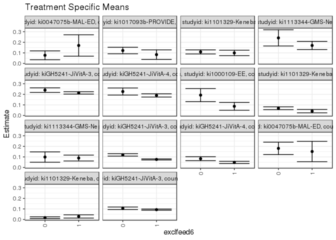

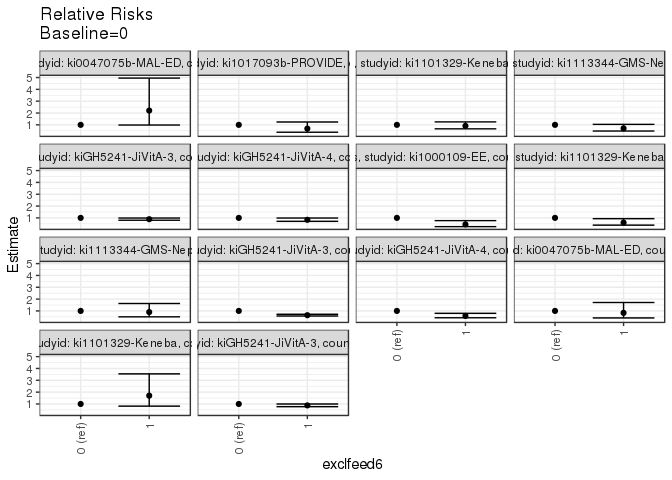

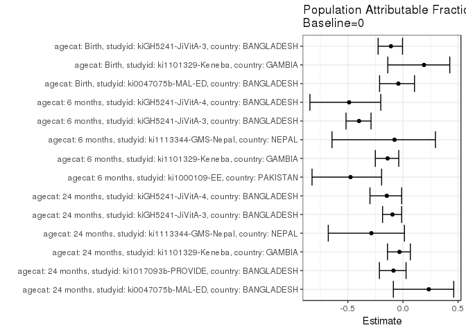

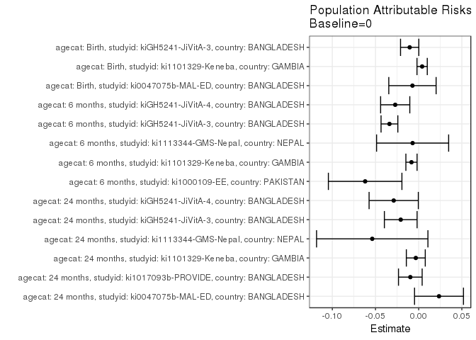

## Results Table

### Parameter: TSM

| agecat | studyid | country | intervention_level | baseline_level | estimate | ci_lower | ci_upper |
| --- | --- | --- | --- | --- | --- | --- | --- |
| Birth | ki0047075b-MAL-ED | BANGLADESH | 0 | NA | 0.1807229 | 0.1220537 | 0.2393920 |
| Birth | ki0047075b-MAL-ED | BANGLADESH | 1 | NA | 0.1509434 | 0.0543429 | 0.2475439 |
| Birth | ki1101329-Keneba | GAMBIA | 0 | NA | 0.0169492 | 0.0084417 | 0.0254566 |
| Birth | ki1101329-Keneba | GAMBIA | 1 | NA | 0.0288248 | 0.0133775 | 0.0442722 |
| Birth | kiGH5241-JiVitA-3 | BANGLADESH | 0 | NA | 0.1059364 | 0.0937500 | 0.1181227 |
| Birth | kiGH5241-JiVitA-3 | BANGLADESH | 1 | NA | 0.0929593 | 0.0873166 | 0.0986021 |
| 6 months | ki1000109-EE | PAKISTAN | 0 | NA | 0.1923077 | 0.1303799 | 0.2542355 |
| 6 months | ki1000109-EE | PAKISTAN | 1 | NA | 0.0863636 | 0.0491958 | 0.1235315 |
| 6 months | ki1101329-Keneba | GAMBIA | 0 | NA | 0.0680787 | 0.0544974 | 0.0816600 |
| 6 months | ki1101329-Keneba | GAMBIA | 1 | NA | 0.0409556 | 0.0249051 | 0.0570062 |
| 6 months | ki1113344-GMS-Nepal | NEPAL | 0 | NA | 0.0985915 | 0.0495140 | 0.1476691 |
| 6 months | ki1113344-GMS-Nepal | NEPAL | 1 | NA | 0.0891089 | 0.0613022 | 0.1169156 |
| 6 months | kiGH5241-JiVitA-3 | BANGLADESH | 0 | NA | 0.1188090 | 0.1073220 | 0.1302961 |
| 6 months | kiGH5241-JiVitA-3 | BANGLADESH | 1 | NA | 0.0759763 | 0.0708602 | 0.0810924 |
| 6 months | kiGH5241-JiVitA-4 | BANGLADESH | 0 | NA | 0.0828025 | 0.0640320 | 0.1015731 |
| 6 months | kiGH5241-JiVitA-4 | BANGLADESH | 1 | NA | 0.0479204 | 0.0372212 | 0.0586197 |
| 24 months | ki0047075b-MAL-ED | BANGLADESH | 0 | NA | 0.0769231 | 0.0350076 | 0.1188386 |
| 24 months | ki0047075b-MAL-ED | BANGLADESH | 1 | NA | 0.1698113 | 0.0684847 | 0.2711379 |
| 24 months | ki1017093b-PROVIDE | BANGLADESH | 0 | NA | 0.1221198 | 0.0912887 | 0.1529510 |
| 24 months | ki1017093b-PROVIDE | BANGLADESH | 1 | NA | 0.0833333 | 0.0381521 | 0.1285146 |
| 24 months | ki1101329-Keneba | GAMBIA | 0 | NA | 0.1090000 | 0.0896784 | 0.1283216 |
| 24 months | ki1101329-Keneba | GAMBIA | 1 | NA | 0.0992218 | 0.0733681 | 0.1250755 |
| 24 months | ki1113344-GMS-Nepal | NEPAL | 0 | NA | 0.2416667 | 0.1649924 | 0.3183410 |
| 24 months | ki1113344-GMS-Nepal | NEPAL | 1 | NA | 0.1699164 | 0.1310269 | 0.2088060 |
| 24 months | kiGH5241-JiVitA-3 | BANGLADESH | 0 | NA | 0.2398504 | 0.2183557 | 0.2613451 |
| 24 months | kiGH5241-JiVitA-3 | BANGLADESH | 1 | NA | 0.2132209 | 0.2020071 | 0.2244347 |
| 24 months | kiGH5241-JiVitA-4 | BANGLADESH | 0 | NA | 0.2263099 | 0.1927519 | 0.2598680 |
| 24 months | kiGH5241-JiVitA-4 | BANGLADESH | 1 | NA | 0.1894543 | 0.1740169 | 0.2048918 |

### Parameter: E(Y)

| agecat | studyid | country | intervention_level | baseline_level | estimate | ci_lower | ci_upper |
| --- | --- | --- | --- | --- | --- | --- | --- |
| Birth | ki0047075b-MAL-ED | BANGLADESH | NA | NA | 0.1735160 | 0.1232462 | 0.2237857 |
| Birth | ki1101329-Keneba | GAMBIA | NA | NA | 0.0209581 | 0.0132741 | 0.0286420 |
| Birth | kiGH5241-JiVitA-3 | BANGLADESH | NA | NA | 0.0955253 | 0.0903072 | 0.1007433 |
| 6 months | ki1000109-EE | PAKISTAN | NA | NA | 0.1303191 | 0.0962457 | 0.1643926 |
| 6 months | ki1101329-Keneba | GAMBIA | NA | NA | 0.0597484 | 0.0491105 | 0.0703864 |
| 6 months | ki1113344-GMS-Nepal | NEPAL | NA | NA | 0.0915751 | 0.0673602 | 0.1157900 |
| 6 months | kiGH5241-JiVitA-3 | BANGLADESH | NA | NA | 0.0849595 | 0.0801414 | 0.0897775 |
| 6 months | kiGH5241-JiVitA-4 | BANGLADESH | NA | NA | 0.0556338 | 0.0463917 | 0.0648759 |
| 24 months | ki0047075b-MAL-ED | BANGLADESH | NA | NA | 0.1004785 | 0.0596222 | 0.1413347 |
| 24 months | ki1017093b-PROVIDE | BANGLADESH | NA | NA | 0.1124567 | 0.0866788 | 0.1382347 |
| 24 months | ki1101329-Keneba | GAMBIA | NA | NA | 0.1056803 | 0.0901896 | 0.1211711 |
| 24 months | ki1113344-GMS-Nepal | NEPAL | NA | NA | 0.1878914 | 0.1528732 | 0.2229097 |
| 24 months | kiGH5241-JiVitA-3 | BANGLADESH | NA | NA | 0.2190767 | 0.2091475 | 0.2290059 |
| 24 months | kiGH5241-JiVitA-4 | BANGLADESH | NA | NA | 0.1974032 | 0.1830515 | 0.2117549 |

### Parameter: RR

| agecat | studyid | country | intervention_level | baseline_level | estimate | ci_lower | ci_upper |
| --- | --- | --- | --- | --- | --- | --- | --- |
| Birth | ki0047075b-MAL-ED | BANGLADESH | 0 | 0 | 1.0000000 | 1.0000000 | 1.0000000 |
| Birth | ki0047075b-MAL-ED | BANGLADESH | 1 | 0 | 0.8352201 | 0.4075190 | 1.7118038 |
| Birth | ki1101329-Keneba | GAMBIA | 0 | 0 | 1.0000000 | 1.0000000 | 1.0000000 |
| Birth | ki1101329-Keneba | GAMBIA | 1 | 0 | 1.7006651 | 0.8160810 | 3.5440866 |
| Birth | kiGH5241-JiVitA-3 | BANGLADESH | 0 | 0 | 1.0000000 | 1.0000000 | 1.0000000 |
| Birth | kiGH5241-JiVitA-3 | BANGLADESH | 1 | 0 | 0.8775016 | 0.7723114 | 0.9970190 |
| 6 months | ki1000109-EE | PAKISTAN | 0 | 0 | 1.0000000 | 1.0000000 | 1.0000000 |
| 6 months | ki1000109-EE | PAKISTAN | 1 | 0 | 0.4490909 | 0.2623603 | 0.7687238 |
| 6 months | ki1101329-Keneba | GAMBIA | 0 | 0 | 1.0000000 | 1.0000000 | 1.0000000 |
| 6 months | ki1101329-Keneba | GAMBIA | 1 | 0 | 0.6015928 | 0.3875429 | 0.9338679 |
| 6 months | ki1113344-GMS-Nepal | NEPAL | 0 | 0 | 1.0000000 | 1.0000000 | 1.0000000 |
| 6 months | ki1113344-GMS-Nepal | NEPAL | 1 | 0 | 0.9038190 | 0.5022605 | 1.6264243 |
| 6 months | kiGH5241-JiVitA-3 | BANGLADESH | 0 | 0 | 1.0000000 | 1.0000000 | 1.0000000 |
| 6 months | kiGH5241-JiVitA-3 | BANGLADESH | 1 | 0 | 0.6394824 | 0.5703692 | 0.7169703 |
| 6 months | kiGH5241-JiVitA-4 | BANGLADESH | 0 | 0 | 1.0000000 | 1.0000000 | 1.0000000 |
| 6 months | kiGH5241-JiVitA-4 | BANGLADESH | 1 | 0 | 0.5787314 | 0.4203782 | 0.7967351 |
| 24 months | ki0047075b-MAL-ED | BANGLADESH | 0 | 0 | 1.0000000 | 1.0000000 | 1.0000000 |
| 24 months | ki0047075b-MAL-ED | BANGLADESH | 1 | 0 | 2.2075472 | 0.9839470 | 4.9527714 |
| 24 months | ki1017093b-PROVIDE | BANGLADESH | 0 | 0 | 1.0000000 | 1.0000000 | 1.0000000 |
| 24 months | ki1017093b-PROVIDE | BANGLADESH | 1 | 0 | 0.6823899 | 0.3752255 | 1.2410032 |
| 24 months | ki1101329-Keneba | GAMBIA | 0 | 0 | 1.0000000 | 1.0000000 | 1.0000000 |
| 24 months | ki1101329-Keneba | GAMBIA | 1 | 0 | 0.9102917 | 0.6642249 | 1.2475157 |
| 24 months | ki1113344-GMS-Nepal | NEPAL | 0 | 0 | 1.0000000 | 1.0000000 | 1.0000000 |
| 24 months | ki1113344-GMS-Nepal | NEPAL | 1 | 0 | 0.7031025 | 0.4754644 | 1.0397268 |
| 24 months | kiGH5241-JiVitA-3 | BANGLADESH | 0 | 0 | 1.0000000 | 1.0000000 | 1.0000000 |
| 24 months | kiGH5241-JiVitA-3 | BANGLADESH | 1 | 0 | 0.8889744 | 0.8011554 | 0.9864198 |
| 24 months | kiGH5241-JiVitA-4 | BANGLADESH | 0 | 0 | 1.0000000 | 1.0000000 | 1.0000000 |
| 24 months | kiGH5241-JiVitA-4 | BANGLADESH | 1 | 0 | 0.8371455 | 0.7088072 | 0.9887210 |

### Parameter: PAR

| agecat | studyid | country | intervention_level | baseline_level | estimate | ci_lower | ci_upper |
| --- | --- | --- | --- | --- | --- | --- | --- |
| Birth | ki0047075b-MAL-ED | BANGLADESH | 0 | NA | -0.0072069 | -0.0346114 | 0.0201975 |
| Birth | ki1101329-Keneba | GAMBIA | 0 | NA | 0.0040089 | -0.0019519 | 0.0099697 |
| Birth | kiGH5241-JiVitA-3 | BANGLADESH | 0 | NA | -0.0104111 | -0.0210016 | 0.0001794 |
| 6 months | ki1000109-EE | PAKISTAN | 0 | NA | -0.0619885 | -0.1045770 | -0.0194001 |
| 6 months | ki1101329-Keneba | GAMBIA | 0 | NA | -0.0083302 | -0.0148121 | -0.0018484 |
| 6 months | ki1113344-GMS-Nepal | NEPAL | 0 | NA | -0.0070165 | -0.0487554 | 0.0347225 |
| 6 months | kiGH5241-JiVitA-3 | BANGLADESH | 0 | NA | -0.0338496 | -0.0435729 | -0.0241263 |
| 6 months | kiGH5241-JiVitA-4 | BANGLADESH | 0 | NA | -0.0271687 | -0.0440655 | -0.0102720 |
| 24 months | ki0047075b-MAL-ED | BANGLADESH | 0 | NA | 0.0235554 | -0.0047887 | 0.0518995 |
| 24 months | ki1017093b-PROVIDE | BANGLADESH | 0 | NA | -0.0096631 | -0.0233589 | 0.0040328 |
| 24 months | ki1101329-Keneba | GAMBIA | 0 | NA | -0.0033197 | -0.0142798 | 0.0076404 |
| 24 months | ki1113344-GMS-Nepal | NEPAL | 0 | NA | -0.0537752 | -0.1182703 | 0.0107199 |
| 24 months | kiGH5241-JiVitA-3 | BANGLADESH | 0 | NA | -0.0207737 | -0.0397167 | -0.0018308 |
| 24 months | kiGH5241-JiVitA-4 | BANGLADESH | 0 | NA | -0.0289067 | -0.0574247 | -0.0003887 |

### Parameter: PAF

| agecat | studyid | country | intervention_level | baseline_level | estimate | ci_lower | ci_upper |
| --- | --- | --- | --- | --- | --- | --- | --- |
| Birth | ki0047075b-MAL-ED | BANGLADESH | 0 | NA | -0.0415346 | -0.2117738 | 0.1047882 |
| Birth | ki1101329-Keneba | GAMBIA | 0 | NA | 0.1912833 | -0.1375800 | 0.4250754 |
| Birth | kiGH5241-JiVitA-3 | BANGLADESH | 0 | NA | -0.1089877 | -0.2252177 | -0.0037838 |
| 6 months | ki1000109-EE | PAKISTAN | 0 | NA | -0.4756672 | -0.8247395 | -0.1933723 |
| 6 months | ki1101329-Keneba | GAMBIA | 0 | NA | -0.1394219 | -0.2505416 | -0.0381760 |
| 6 months | ki1113344-GMS-Nepal | NEPAL | 0 | NA | -0.0766197 | -0.6435372 | 0.2947467 |
| 6 months | kiGH5241-JiVitA-3 | BANGLADESH | 0 | NA | -0.3984203 | -0.5163793 | -0.2896373 |
| 6 months | kiGH5241-JiVitA-4 | BANGLADESH | 0 | NA | -0.4883496 | -0.8441028 | -0.2012261 |
| 24 months | ki0047075b-MAL-ED | BANGLADESH | 0 | NA | 0.2344322 | -0.0870450 | 0.4608374 |
| 24 months | ki1017093b-PROVIDE | BANGLADESH | 0 | NA | -0.0859270 | -0.2135095 | 0.0282421 |
| 24 months | ki1101329-Keneba | GAMBIA | 0 | NA | -0.0314125 | -0.1404304 | 0.0671840 |
| 24 months | ki1113344-GMS-Nepal | NEPAL | 0 | NA | -0.2862037 | -0.6774310 | 0.0137777 |
| 24 months | kiGH5241-JiVitA-3 | BANGLADESH | 0 | NA | -0.0948240 | -0.1848562 | -0.0116329 |
| 24 months | kiGH5241-JiVitA-4 | BANGLADESH | 0 | NA | -0.1464348 | -0.2992619 | -0.0115841 |